# Genomics Workshop in Todos Santos!

Please join us in Todos Santos April 9-13, 2018. Here is a summary of the topics that we are looking forward to covering.

### Monday: Introduction to high-throughput sequencing and computational biology

- **09:00-10:30** Introduction to Todos Santos and Group Discussion
- **10:30-11:00** Introduction to Computational Biology
- **11:00-12:00** UNIX and Command Line Tools **[Unix Resources]**
- **12:00-13:00** Lunch
- **13:00-14:00** High-Throughput Sequencing Technologies
- **14:00-16:00** Manipulating Genomics Data
- **16:00-17:00** Experimental Design for Genomics Research

### Tuesday: R, data visualization, and microbiome analysis

- **09:00-09:30** Introduction to R, R Markdown, and Data Visualization
- **09:30-10:15** Plotting Genomic Data with R and ggplot
- **10:15-11:00** Figure Drawing in R
- **11:00-12:00** Circular Representations of Genomic Data with Circos
- **12:00-13:00** Lunch
- **13:00-16:00** 16S rRNA Amplicon Sequencing and Microbial Diversity
- **16:00-18:00** Poster Session and Lightning Talks (with refreshments)

### Wednesday: Comparative (meta)genomic analysis

- **09:00-10:30** Assembly and Annotation
- **10:30-12:00** Alignment and Read Mapping
- **12:00-13:00** Lunch
- **13:00-18:00** Local excursion to Sancuary Cacti and El Triunfo.

### Thursday: Comparative genomics (cont.), RNA-seq, and differential gene expression

- **09:00-11:00** Metagenomics
- **11:00-12:00** Variant Calling
- **12:00-13:00** Lunch
- **13:00-17:00** RNA-seq data analysis

### Friday: RNA-seq (cont.), Python and GitHub

- **09:00-12:00** RNA-seq data analysis (cont.)
- **12:00-13:00** Lunch
- **13:00-15:30** Python Scripting
- **15:30-16:00** Code Management (GitHub)
- **16:00-18:00** Farewell Refreshments and Informal Project Discussions

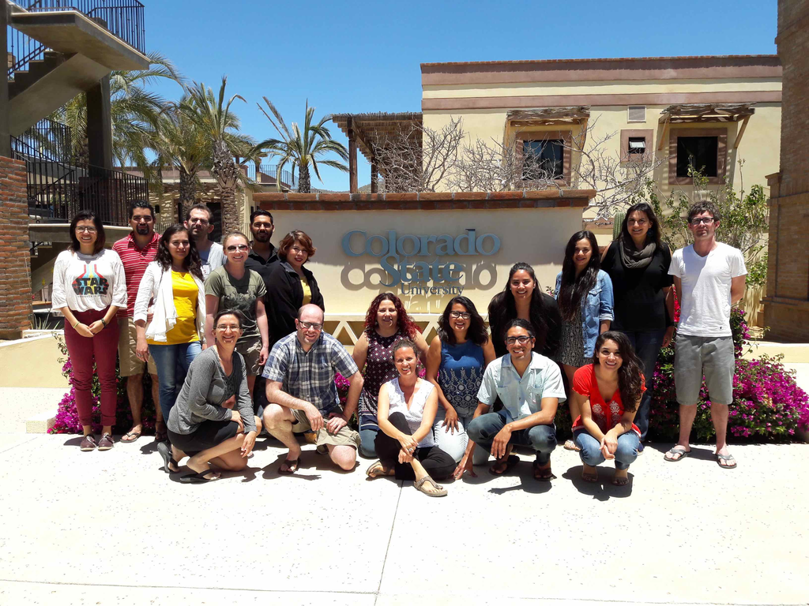

[figure not shown]

Supported by the National Science Foundation (MCB-1733227).